# Part II - Bike Sharing Usage Patterns and Trip Duration Analysis

## Investigation Overview - Dataset Overview and Executive Summary

This analysis investigates how bike-sharing usage patterns and trip duration vary across different factors such as time of day, user type, and user age.

The dataset consists of bike trip records, including duration, start time, and user information. Additional features such as hour of day and age were derived to support deeper analysis. Data cleaning steps were performed to handle missing values and remove unrealistic entries.

These findings are supported by multiple visualizations, including bar charts, histograms (with log transformation), and heatmaps. Each visualization is carefully selected to match the data type and clearly communicate patterns and relationships.

All visualizations are polished with appropriate titles, labeled axes (with units) to ensure readability and effective communication of insights.

```python
# import all packages and set plots to be embedded inline
import numpy as np
import pandas as pd
import matplotlib.pyplot as plt
import seaborn as sns

# suppress warnings from final output
import warnings
warnings.simplefilter("ignore")
```

```python
# load in the dataset into a pandas dataframe
df = pd.read_csv("fordgobike-tripdata.csv")
```

```python
# some cleaning steps so I can plot
df['start_time'] = pd.to_datetime(df['start_time'])
df['end_time'] = pd.to_datetime(df['end_time'])
df['start_hour'] = df['start_time'].dt.hour
df['start_day'] = df['start_time'].dt.day_name()
df['start_month'] = df['start_time'].dt.month_name()
df['age'] = df['start_time'].dt.year - df['member_birth_year']
df = df[df['duration_sec'] < 3600]
df = df[(df['age'] > 10) & (df['age'] < 80)]
```

## Bike Usage by Hour

> This visualization shows the distribution of bike trips across different hours of the day. Bike usage peaks during morning (around 8 AM) and evening (around 5–6 PM), indicating strong commuting patterns. Usage is lowest during late night and early morning hours. The bar chart is appropriate for showing frequency across discrete time intervals and clearly highlights peak usage periods.

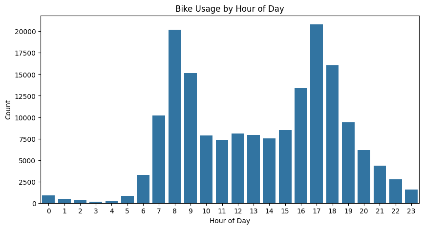

```python
def plot_count(data, column, title='', xlabel='', rotation=0):
    plt.figure(figsize=(10,5))
    sns.countplot(data=data, x=column)
    plt.title(title)
    plt.xlabel(xlabel)
    plt.ylabel('Count')
    plt.xticks(rotation=rotation)
    plt.show()

plot_count(df, 'start_hour', title='Bike Usage by Hour of Day', xlabel='Hour of Day')
```

## Trip Duration Distribution

> This visualization illustrates the distribution of trip durations. The distribution is right-skewed, with most trips being short and a small number of long-duration outliers. A log transformation was applied to better visualize the spread of the data. A histogram is suitable here as it effectively shows the distribution and skewness of the variable.

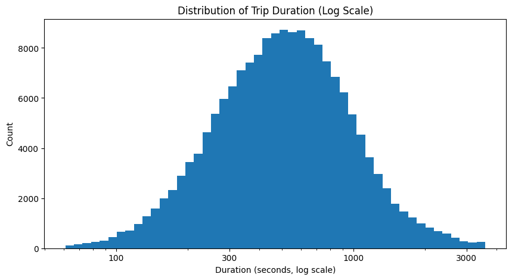

```python
plt.figure(figsize=(10,5))
bins = np.logspace(np.log10(df['duration_sec'].min()), np.log10(df['duration_sec'].max()), 50)
plt.hist(df['duration_sec'], bins=bins)
plt.xscale('log')
plt.xticks([100, 300, 1000, 3000],['100', '300', '1000', '3000'])
plt.title('Distribution of Trip Duration (Log Scale)')
plt.xlabel('Duration (seconds, log scale)')
plt.ylabel('Count')
plt.show()
```

## Average Trip Duration by Hour and User Type (Heatmap)

> This visualization shows how average trip duration varies by hour of the day and user type. Customers consistently have longer trip durations than Subscribers, especially during midday hours. Subscribers show shorter and more stable trip durations throughout the day. The heatmap is appropriate for displaying relationships between multiple variables and allows easy comparison across time and user groups.

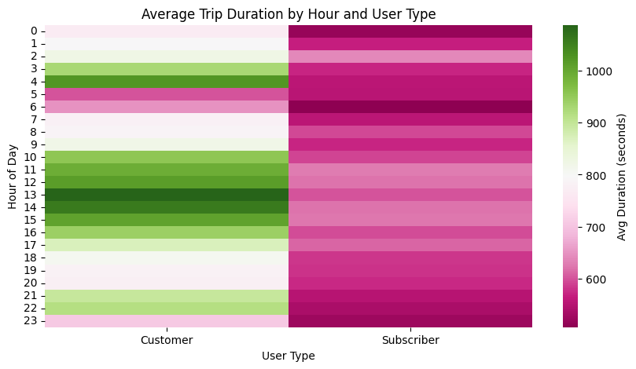

```python
heat_data = df.groupby(['start_hour', 'user_type'])['duration_sec'].mean().reset_index()
heat_data = heat_data.pivot(index='start_hour', columns='user_type', values='duration_sec')
plt.figure(figsize=(10,5))
sns.heatmap(heat_data, cmap='PiYG', cbar_kws={'label': 'Avg Duration (seconds)'})
plt.title('Average Trip Duration by Hour and User Type')
plt.xlabel('User Type')
plt.ylabel('Hour of Day')
plt.show()
```